# Lecture #17

함수 그리기 및 겹쳐 그리기

Junho Ahn

2022-09-08

## lines, points 및 text 함수

### 기능과 사용함수

- `lines()`함수: 기존 함수에 선을 추가
- `points()`함수: 기존 함수에 점을 추가
- `text()`함수: 기존 그래픽에 문자열을 추가

### 선, 점, 문자열 추가하기

(히스토그램에 꺾은선 그래프 추가)  
* hist함수는 그림 뿐만 아니라 그림을 그리기 위해 필요한 값을 출력  
* hist함수의 출력 중 mid는 히스토그램의 기둥에서 가로축의 중간점 좌표를 저장하며  
* count는 각 기둥의 빈도수를 저장함  
* 히스토그램을 그린 후 mid와 count 값을 사용하여 꺾은선을 lines함수를 사용하여 추가

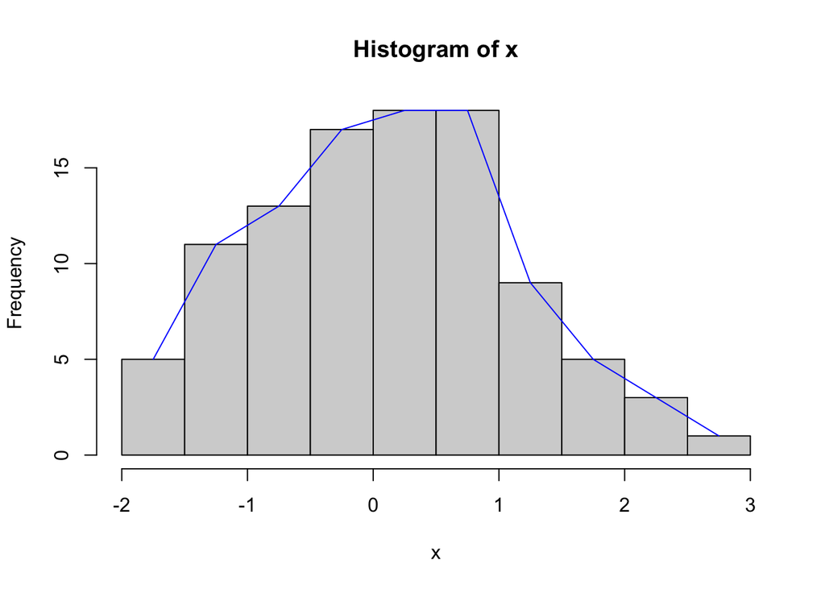

```r
x <- rnorm(100)
hist.res <- hist(x)
lines(hist.res$mid, hist.res$count, col = rgb(0,0,1))
```

- x: 100개의 표준정규분포 난수를 생성
- hist.res: hist 함수를 호출하여 중간 계산값을 저장하고, 이 때 hist함수에 의해 히스토그램이 만들어짐
- lines: hist.res에 저장한 mid 값과 해당 기둥의 빈도수를 연결하는 선을 lines함수로 그림

(막대그래프에 선과 문자열 추가)  
* 막대그래프는 barplot함수를 호출할 때 각 기둥의 중간점의 좌표가 계산됨  
* 빈도수는 막대그래프를 그릴 때 사용함  
* 따라서 위와 비슷한 방법으로 꺾은 선을 추가할 수 있음

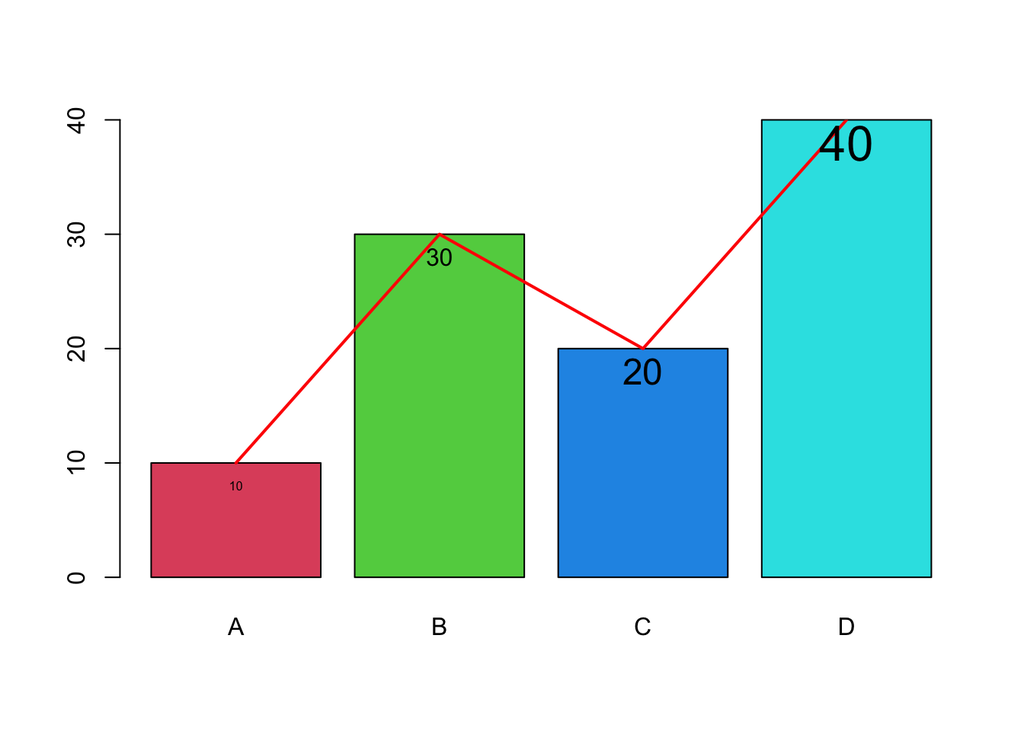

```r
freq <- c(10, 30, 20, 40)
cat <- c("A", "B", "C", "D")
bp.res <- barplot(freq, names.arg = cat, col = 2:5)
lines(bp.res, freq, col = rgb(1,0,0), lwd = 2)
text(bp.res, freq-2, as.character(freq), cex = seq(0.5,2,length=4))
```

- barplot함수로 막대그래프를 그린 후, 각 기둥의 좌표와 빈도를 연결하는 선을 lines함수를 사용하여 그림
- 마지막의 text함수로 각 기둥의 빈도값을 추가로 출력함
- 이 때 문자열은 빈도수로 문자의 크기는 0.5부터 2까지 바꾸었음

(빈 산점도 만들고 사분면 표시하기) 좌표평면을 사분면으로 나누고 문자열로 표시

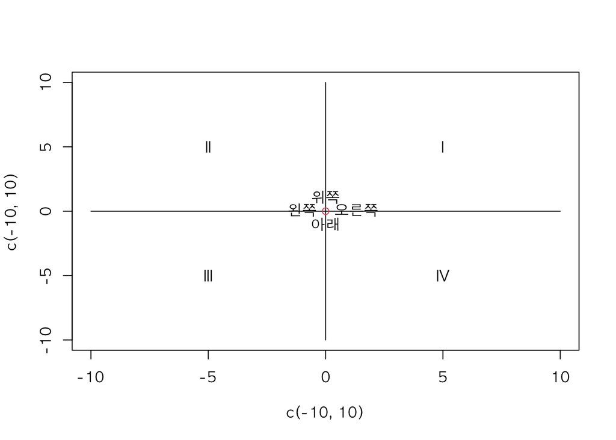

```r
par(family = "AppleGothic")
plot(c(-10,10), c(-10,10), type = "n")
lines(c(-10,10), c(0,0))
lines(c(0,0), c(-10,10))
points(0,0,col = 2)
text(c(5,-5,-5,5), c(5,5,-5,-5), labels = c("I", "II", "III", "IV"))
text(0,0, pos=c(1,2,3,4), labels = c("아래", "왼쪽", "위쪽", "오른쪽"))
```

(그룹별 표시 방법 변경) BMI자료에서 키와 몸무게를 성별에 따라 서로 다른 점으로 표시하기를 `points()`함수를 사용하여 구현해보자.

```r
plot.test2 <- function(){
  BMI <- read.table("./bmi.txt",
                    col.names = c("height","weight","year","religion","gender","marriage"))
  plot(BMI$height, BMI$weight, type = "n")
  points(BMI[BMI$gender == "F",]$height, BMI[BMI$gender == "F",]$weight, pch = 16, col = "red")
  points(BMI[BMI$gender == "M",]$height, BMI[BMI$gender == "M",]$weight, pch = 15, col = "blue")
}
```

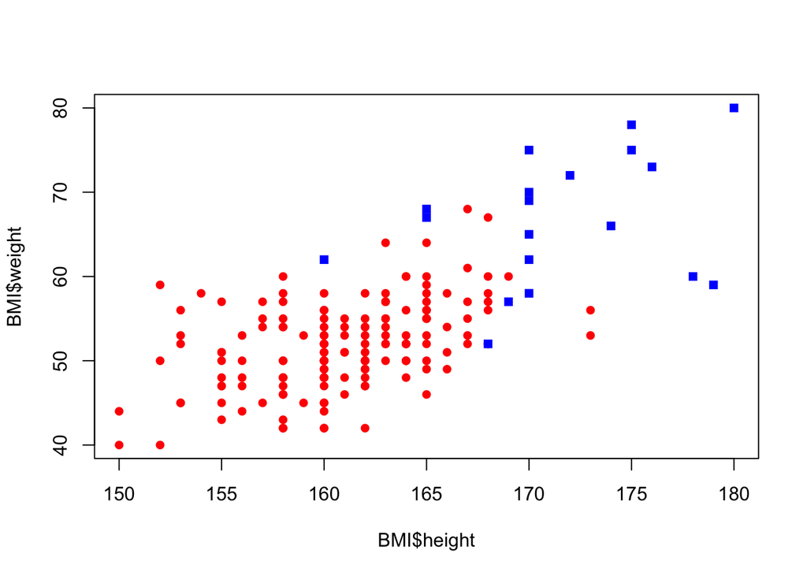

```r
plot.test2()
```

## abline 함수

### 기능과 사용함수

abline함수: 직선 $y=a+bx$를 기존의 그래픽에 추가

### abline 함수로 직선 추가하기

(예시) 키와 몸무게 자료 BMI를 사용하여 키와 몸무게에 대한 산점도를 그리고 이 그림에 키와 몸무게의 평균값을 지나는 가로축과 세로축을 그리는 경우를 구현해보자

- 먼저 plot(ht, wt)로 산점도를 그림
- abline(v=mean(ht))로 ht의 평균을 지나는 수직선을 그림
- abline(h=mean(wt))로 wt의 평균을 지나는 수평선을 그림

```r
BMI <- read.table("./bmi.txt",
                    col.names = c("height","weight","year","religion","gender","marriage"))
```

```r
abline.test <- function(){
  ht <- BMI$height
  wt <- BMI$weight
  plot(ht, wt)
  abline(v=mean(ht), lty = 2, col = "blue")
  abline(h=mean(wt), lty = 2, col = "blue")
}
```

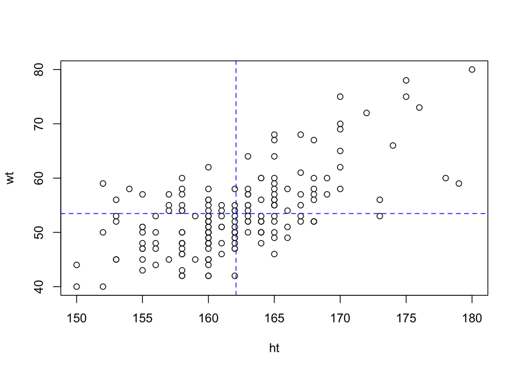

```r
abline.test()
```

## legend함수

### 기능과 사용함수

legend함수는 matplot함수에 범례를 추가할 수 있음

### legend함수로 범례 추가하기

```r
df <- readxl::read_xlsx("./grdp.xlsx", skip = 1)
head(df)
```

| ...1 | 2006 | 2007 | 2008 | 2009 | 2010 | 2011 | 2012 | 2013 | 2014 |
| --- | --- | --- | --- | --- | --- | --- | --- | --- | --- |
| 전국 | 966660 | 1043255 | 1105722 | 1151367 | 1265146 | 1330888 | 1377041 | 1430255 | 1484542 |
| 서울 | 231224 | 249485 | 263000 | 273199 | 289719 | 303813 | 313479 | 318607 | 327602 |
| 부산 | 52358 | 56193 | 60467 | 60695 | 63737 | 66648 | 67999 | 70338 | 73744 |
| 대구 | 32276 | 34388 | 35465 | 36017 | 38580 | 41448 | 43021 | 44754 | 46592 |
| 인천 | 47055 | 51638 | 51274 | 53796 | 60708 | 61854 | 62208 | 64654 | 68374 |
| 광주 | 20614 | 22310 | 22940 | 23834 | 26401 | 27789 | 28914 | 29763 | 30998 |

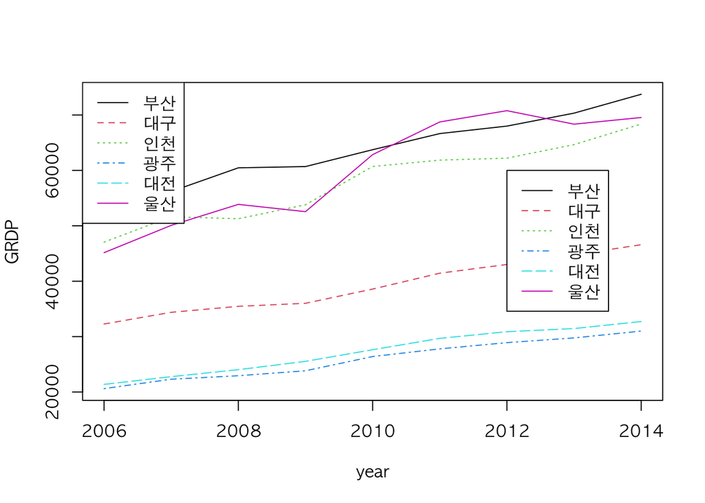

```r
legend <- unlist(as.vector(df[3:8,1]))
par(family = "AppleGothic")
matplot(seq(2006, 2014), t(df[3:8, -1]), type = "l", xlab = "year", ylab = "GRDP")
legend(x = "topleft", legend = legend, lty = 1:5, col = 1:6)
legend(2012, 60000, legend = legend, lty = 1:5, col = 1:6)
```

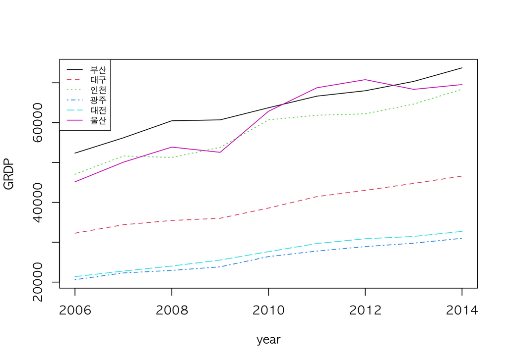

```r
par(family = "AppleGothic")
matplot(seq(2006, 2014), t(df[3:8, -1]), type = "l", xlab = "year", ylab = "GRDP")
legend(x = "topleft", legend = legend, lty = 1:5, col = 1:6, cex = 0.7)
```